# DC-TAP-seq positives × ENCODE ChIP-seq overlap and enrichment

Generated 2026-07-06 · hg38 / GRCh38 · Input: Table S3 (resized/merged element coordinates)

**Scope.** This report checks overlap of the randomly-selected DC-TAP-seq positive elements against the full ENCODE catalog of transcription factors and histone marks in unperturbed K562 and WTC11 cells, extending the H3K27ac / H3K27me3 / CTCF analysis in the manuscript.

## 1. Summary

We tested whether DC-TAP-seq **positive** distal elements (randomly selected `Random_DistalElement_Gene` pairs called `significant`) overlap ENCODE ChIP-seq peaks for the full catalog of transcription factors and histone marks in unperturbed cells — well beyond the H3K27ac / H3K27me3 / CTCF marks used in the original manuscript. Positives are split by effect-size sign, and overlap is compared against tested-but-non-significant background elements.

**Key result.** DC-TAP-seq **negative-effect** positives (elements whose repression *lowers* target expression — i.e. canonical activating enhancers) are strongly and specifically enriched for TF and histone-mark occupancy relative to background, in both K562 and WTC11. **Positive-effect** positives show essentially no enrichment (0 targets at FDR<0.1 in either cell type against the well-powered background), consistent with them being a mechanistically distinct or noisier group.

### Element set sizes (unique element loci)

| Cell type | Positives (neg. effect) | Positives (pos. effect) | Background (well-powered) | Background (all non-sig.) |
| --- | --- | --- | --- | --- |
| K562 | 18 | 29 | 373 | 599 |
| WTC11 | 47 | 25 | 476 | 655 |

Element loci are the resized/merged hg38 intervals (`resized_merged_targeting_*_hg38`). An element is a "positive" if it is a significant hit for ≥1 gene; sign groups are assigned by whether any significant pair at that element has negative / positive log2 fold-change. Background = elements never significant; "well-powered" additionally requires `power_at_effect_size_15 > 0.8`. A few elements are hits with both signs (1 K562, 4 WTC11) and appear in both positive groups.

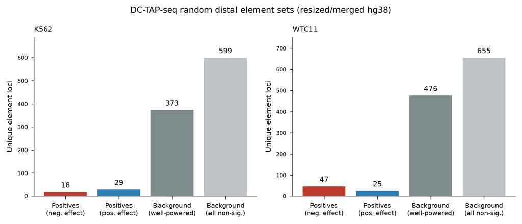

## 2. ENCODE data — curation of unperturbed cells

ChIP-seq experiments were queried from the ENCODE portal REST API restricted to `status=released`, `assembly=GRCh38`. We queried three histone-type assay categories — `TF ChIP-seq`, `Histone ChIP-seq` and `Mint-ChIP-seq` — because on ENCODE the native WTC11 histone data are generated exclusively by **Mint-ChIP-seq** (there is no conventional Histone ChIP-seq for WTC11). For the WTC11 arm we include WTC11 itself plus the closest ENCODE iPSC/ESC lines **H1** and **H9**: WTC11 supplies native TF ChIP-seq (87 targets) and native Mint-ChIP-seq for 6 core histone marks (H3K27ac, H3K27me3, H3K4me1, H3K4me3, H3K9me3, H3K36me3, including both key histone marks); H1/H9 supply the additional 22 histone marks not assayed natively in WTC11.

**Unperturbed-cells filter.** We **excluded** any experiment whose biosample carried a chemical/protein treatment (e.g. interferon α/γ) or a *perturbing* genetic modification (gene over-expression, knockout/knockdown, CRISPRi). We **kept** unmodified cells and cells carrying only an *endogenous epitope tag* (`purpose=tagging, perturbation=false`, e.g. 3×FLAG / eGFP knock-in used to enable the ChIP) — these do not perturb cell state. Every excluded experiment and reason is in encode_excluded_audit.csv.

| Cell set | Distinct experiments queried | Selected (one per target, unperturbed, hg38 peak) | Unique targets | TF | Histone |
| --- | --- | --- | --- | --- | --- |
| K562 | 559 | 536 | 536 | 524 | 12 |
| WTC11 + H1 + H9 | 185 | 168 | 168 | 140 | 28 |

**One experiment per target.** To keep overlap calls comparable across targets, exactly one ChIP-seq experiment is used per (cell set, target): experiments are ranked first by **assay type — conventional TF/Histone ChIP-seq is preferred over Mint-ChIP-seq** whenever both exist for the same mark in the same cell line (so a real ChIP-seq experiment is never displaced by the low-input multiplexed Mint assay; Mint is used only where it is the sole source, e.g. all native WTC11 histone marks) — then by lab (Bradley Bernstein > Michael Snyder > John Stamatoyannopoulos), then by fewest ENCODE audit flags (ERROR, then NOT_COMPLIANT, then WARNING), and the top experiment is retained (298 additional experiments dropped as duplicate targets). The three manuscript K562 marks resolve to the Bernstein-lab experiments ENCSR000AKP (H3K27ac), ENCSR000AKO (CTCF), ENCSR000AKQ (H3K27me3). Excluded upstream of this: 22 K562 interferon-treated experiments + 1 K562 (FOS) lacking any GRCh38 peak; 3 WTC11 TALEN over-expression constructs; 66 H1/H9 experiments for targets where native WTC11 data exist (including all H1/H9 experiments for the 6 histone marks now covered by native WTC11 Mint-ChIP-seq). iPSC/ESC composition by line and assay:

| assay | term_name | Histone ChIP-seq | Mint-ChIP-seq | TF ChIP-seq |
| --- | --- | --- | --- | --- |
|  | H1 | 14 | 0 | 53 |
|  | H9 | 8 | 0 | 0 |
|  | WTC11 | 0 | 6 | 87 |

## 3. Overlap heatmaps: positive elements × ChIP-seq targets

Binary overlap (element locus vs the single selected GRCh38 narrowPeak file per target; see §2 for the one-experiment-per-target rule). Following the manuscript, broad histone marks were extended ±175 bp (applied to both `Histone ChIP-seq` and `Mint-ChIP-seq` peaks); TF/point-source peaks were left unextended. Columns are limited to **informative targets** (enriched at FDR<0.1 in either sign, or overlapping ≥25% of positives). **Rows are ordered by manuscript chromatin category** (High H3K27ac → H3K27ac → No H3K27ac → CTCF element → H3K27me3 element), split by effect sign — negative-effect elements above the red line, positive-effect below. The three manuscript marks (**H3K27ac, H3K27me3, CTCF**) are pinned to the far left (red bold labels) so the expected trends are immediate; remaining columns are ordered histone marks then TFs (blue dashed divider). Two left annotation strips encode the element's manuscript `element_category` (color) and whether its minimum element-to-TSS distance is **<100 kb** (filled = near).

### K562

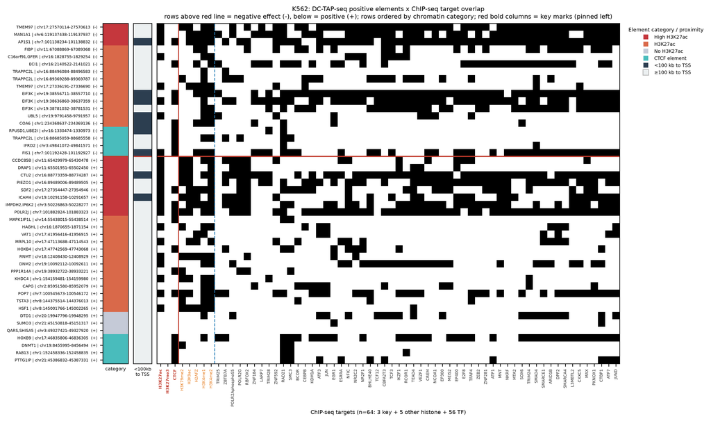

### WTC11 (vs WTC11/H1/H9 ChIP-seq)

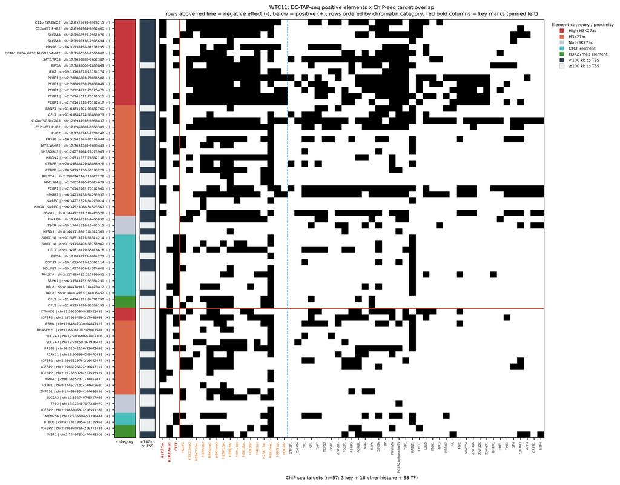

## 4. Per-target enrichment (positives vs background)

For each ChIP-seq target we test overlap in positives vs background with a two-sided Fisher's exact test and Benjamini–Hochberg FDR. **Primary** background = well-powered non-significant elements; an **all-non-significant** sensitivity analysis is included in the CSVs. Analyses run separately for negative- and positive-effect positives. Full tables: enrichment_K562.csv, enrichment_WTC11.csv.

### K562 — negative-effect positives vs well-powered background (top 20 by FDR)

| target | assay | pos_ov | n_pos | pos_% | bg_% | OR | log2OR | p_value | FDR |
| --- | --- | --- | --- | --- | --- | --- | --- | --- | --- |
| ZNF184 | TF | 6 | 18 | 33% | 3% | 16.5 | 4.03 | 3.6e-05 | 1.8e-02 |
| TRIM28 | TF | 7 | 18 | 39% | 6% | 9.7 | 3.28 | 1.4e-04 | 2.2e-02 |
| E2F8 | TF | 7 | 18 | 39% | 6% | 9.3 | 3.22 | 1.7e-04 | 2.2e-02 |
| MTA2 | TF | 8 | 18 | 44% | 9% | 8.0 | 2.99 | 1.8e-04 | 2.2e-02 |
| SMAD4 | TF | 12 | 18 | 67% | 26% | 5.7 | 2.45 | 5.1e-04 | 4.2e-02 |
| LARP7 | TF | 5 | 18 | 28% | 3% | 11.6 | 3.56 | 5.1e-04 | 4.2e-02 |
| TRIM24 | TF | 9 | 18 | 50% | 14% | 5.9 | 2.55 | 6.3e-04 | 4.4e-02 |
| TRIM25 | TF | 4 | 18 | 22% | 2% | 14.9 | 3.92 | 8.6e-04 | 5.2e-02 |
| TCF12 | TF | 7 | 18 | 39% | 9% | 6.6 | 2.73 | 9.5e-04 | 5.2e-02 |
| NCOA1 | TF | 7 | 18 | 39% | 9% | 6.3 | 2.68 | 1.1e-03 | 5.5e-02 |
| MTA1 | TF | 7 | 18 | 39% | 11% | 5.3 | 2.43 | 2.7e-03 | 1.0e-01 |
| SMARCA5 | TF | 6 | 18 | 33% | 8% | 5.9 | 2.60 | 2.8e-03 | 1.0e-01 |
| HDGF | TF | 6 | 18 | 33% | 8% | 5.9 | 2.60 | 2.8e-03 | 1.0e-01 |
| ZNF319 | TF | 4 | 18 | 22% | 3% | 10.4 | 3.43 | 2.4e-03 | 1.0e-01 |
| TCF3 | TF | 10 | 18 | 56% | 23% | 4.3 | 2.08 | 3.2e-03 | 1.1e-01 |
| ZEB2 | TF | 7 | 18 | 39% | 12% | 4.5 | 2.20 | 5.5e-03 | 1.4e-01 |
| RLF | TF | 5 | 18 | 28% | 6% | 5.9 | 2.60 | 5.8e-03 | 1.4e-01 |
| LCOR | TF | 6 | 18 | 33% | 9% | 5.2 | 2.40 | 5.1e-03 | 1.4e-01 |
| NBN | TF | 7 | 18 | 39% | 12% | 4.5 | 2.20 | 5.5e-03 | 1.4e-01 |
| NKRF | TF | 6 | 18 | 33% | 9% | 5.2 | 2.40 | 5.1e-03 | 1.4e-01 |

### WTC11 — negative-effect positives vs well-powered background (top 20 by FDR)

[output not shown]

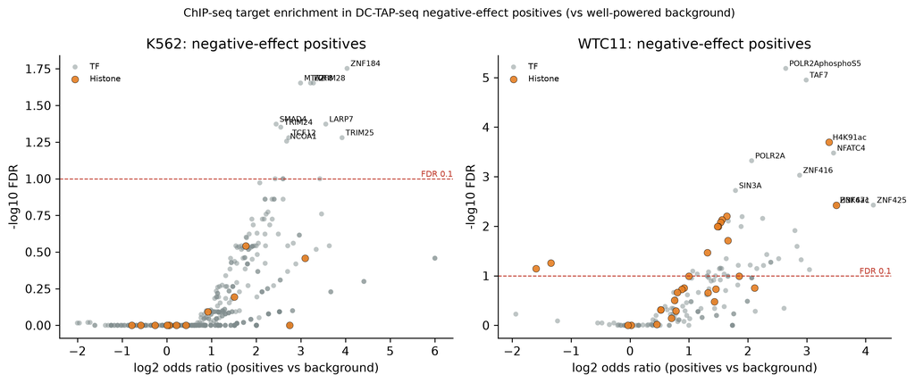

Volcano: log2 odds ratio vs −log10 FDR for negative-effect positives. Histone marks highlighted in orange; dashed line = FDR 0.1.

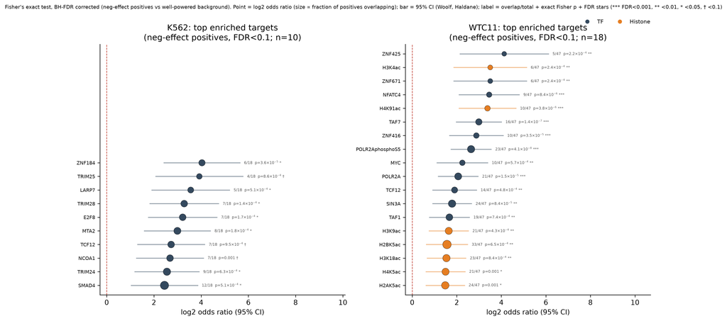

Top enriched targets by FDR. Point = log2 odds ratio (marker size ∝ fraction of positives overlapping); horizontal bar = 95% CI on the log2 OR (Woolf method, Haldane-Anscombe 0.5 correction). Each label gives overlap/total, the **exact two-sided Fisher's-exact p-value**, and BH-adjusted significance stars (*** FDR<0.001, ** <0.01, * <0.05, † <0.1). A full-length version with every FDR<0.1 target is provided as dotplot_neg_powered_all.png/.pdf. Complete per-target statistics for every cell/effect-sign/background combination are in tables/enrichment_by_assay.csv; per-element overlap calls with annotations are in tables/overlap_by_element.csv.

**Positive-effect positives.** Against the well-powered background, **0** targets reach FDR<0.1 in either K562 or WTC11 for positive-effect positives (WTC11 shows 1 target only against the all-non-significant background). This asymmetry is the clearest single finding and motivates treating the two sign groups separately.

## 5. Draft reply to the reviewer

We thank the reviewer for this suggestion. We have now systematically intersected our randomly-selected DC-TAP-seq elements with the complete catalog of ENCODE ChIP-seq experiments in unperturbed cells for both cell types. For K562 this comprised 536 ChIP-seq experiments spanning 536 unique targets (524 transcription factors and 12 histone marks); for WTC11 the native histone data on ENCODE come exclusively from Mint-ChIP-seq (there is no conventional Histone ChIP-seq for WTC11), so we queried TF ChIP-seq, Histone ChIP-seq and Mint-ChIP-seq and additionally included the closest ENCODE iPSC/ESC lines (H1, H9) to cover histone marks not natively assayed in WTC11, giving 168 experiments across 168 targets (140 TFs, 28 histone marks). The two histone marks central to the manuscript's WTC11 categorization — H3K27ac and H3K27me3 — are both available as native WTC11 Mint-ChIP-seq.

This analysis largely recapitulates the chromatin picture captured by our original chromatin categories, with active enhancers (significant hits with negative effect size) carrying TF and histone-mark occupancy. We found that DC-TAP-seq negative-effect positives are broadly and significantly enriched for TF and histone-mark occupancy relative to background: 10 targets in K562 and 43 in WTC11 reach FDR<0.1, with top-ranked factors (ZNF184, TRIM28, E2F8, MTA2, SMAD4, LARP7 in K562; POLR2AphosphoS5, TAF7, H4K91ac, NFATC4, POLR2A, ZNF416 in WTC11) dominated by general transcriptional/enhancer-associated machinery rather than a single specific factor. On the other hand, positive-effect positives show essentially no enrichment.

Counts are generated directly from the pipeline outputs at report-build time.

## 6. Methods & reproducibility

The pipeline takes **Table S3** as its only biological input and is fully scripted:

1. **Element sets** — build_element_sets.py: parses Table S3, filters to `Random_DistalElement_Gene==True` per cell type, dedups to element loci, writes BED files.
2. **ENCODE curation** — curate_encode_metadata.py: re-queries the ENCODE portal, applies the unperturbed filter, selects one preferred narrowPeak per experiment → encode_selected_files.csv.
3. **Download** — download_encode.py: md5-verified, resumable download of ~1,016 files (~340 MB). See README_download.md.
4. **Overlap + enrichment** — compute_overlap_enrichment.py: pyranges overlap (histone ±175 bp), Fisher's exact + BH-FDR.

**Validation.** Our overlap calls reproduce the manuscript's `element_category` exactly: elements labelled "High H3K27ac" overlap our H3K27ac peaks 100%, "No H3K27ac" 0%, "CTCF element" overlap CTCF 100%, and "H3K27me3 element" overlap H3K27me3 100%.

Caveats: positive sets are small (K562 neg n=18, WTC11 neg n=47), so individual-TF ORs have wide CIs; enrichment is driven partly by general element activity/accessibility rather than TF-specific binding. Exactly one ENCODE experiment is used per target (lab priority Bernstein > Snyder > Stamatoyannopoulos, then fewest audit flags), so overlap calls are comparable across targets rather than pooled over heterogeneous pipelines.